# Homework 1 - IE582 - Fall 2020

Irem Arica

20 11 2020

```r
# reading the data
data20182019 <- read.csv("/Users/iremarica/Desktop/homework1/20182019.csv")
data20192020 <- read.csv("/Users/iremarica/Desktop/homework1/20192020.csv")
data20202021 <- read.csv("/Users/iremarica/Desktop/homework1/20202021.csv")

# libraries
library(data.table, warn.conflicts = FALSE)
library(ggplot2, warn.conflicts = FALSE)
library(dplyr, warn.conflicts = FALSE)

# combining data
dataset <- rbindlist(list(data20182019, data20192020, data20202021),
    fill = TRUE)
```

## Task 1

### Part 1

At first, a variable for differences between Home Goals and Away Goals is created. Histograms for Home Goals, Away Goals and Home Goals - Away Goals are below.

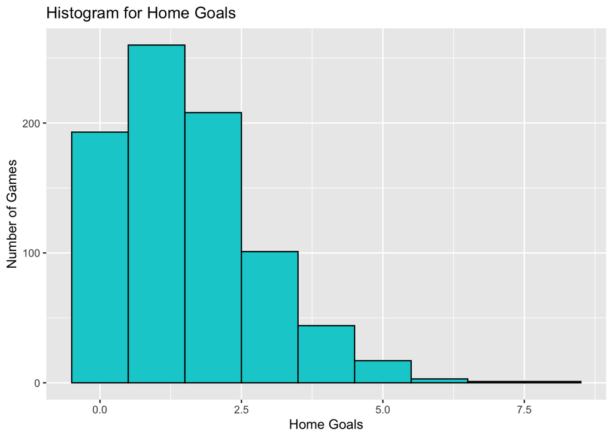

```r
dataset$home_away <- as.numeric(dataset$FTHG - dataset$FTAG)
qplot(dataset$FTHG, geom = "histogram", xlab = "Home Goals",
    ylab = "Number of Games", main = "Histogram for Home Goals",
    col = I("black"), fill = I("darkturquoise"), binwidth = 1)
```

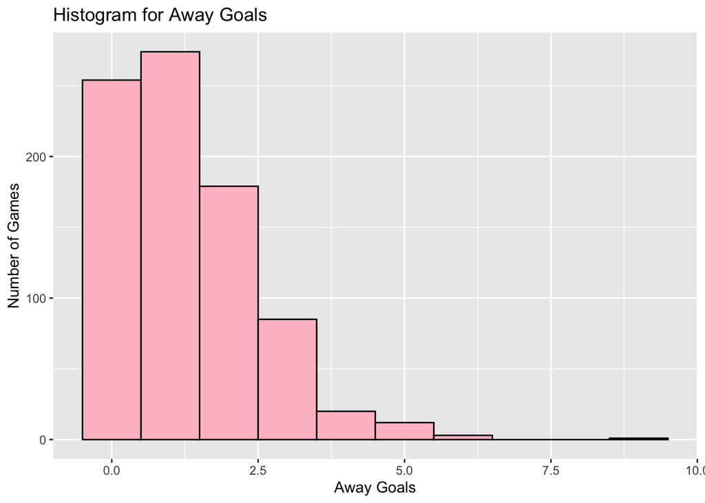

```r
qplot(dataset$FTAG, geom = "histogram", xlab = "Away Goals",
    ylab = "Number of Games", main = "Histogram for Away Goals",
    col = I("black"), fill = I("pink"), binwidth = 1)
```

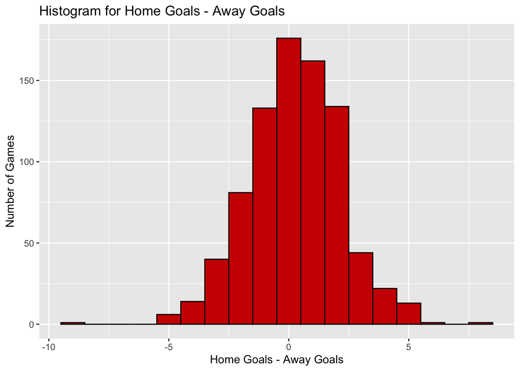

```r
qplot(dataset$home_away, geom = "histogram", xlab = "Home Goals - Away Goals",
    main = "Histogram for Home Goals - Away Goals", ylab = "Number of Games",
    col = I("black"), fill = I("red3"), binwidth = 1)
```

### Part 2

The distribution of Home and Away Goals are fitting well to Poisson distribution.

```r
xfit <- seq(min(dataset$FTHG), max(dataset$FTHG))
yfit <- dpois(xfit, lambda = mean(dataset$FTHG))
mean(dataset$FTHG)
```

```
## [1] 1.53744
```

The sample mean of Home Goals is 1.53 and it is used as Poisson distribuion mean. The expected number of games for each quantile in Poisson distribution is as follows. It can be seen in the following histogram.

```r
exppois <- as.numeric(length(dataset$FTHG) * yfit)
exppois
```

```
## [1] 177.9626222 273.6067852 210.3269550 107.7883308  41.4295124  12.7390747
## [7]   3.2642597   0.7169432   0.1377821
```

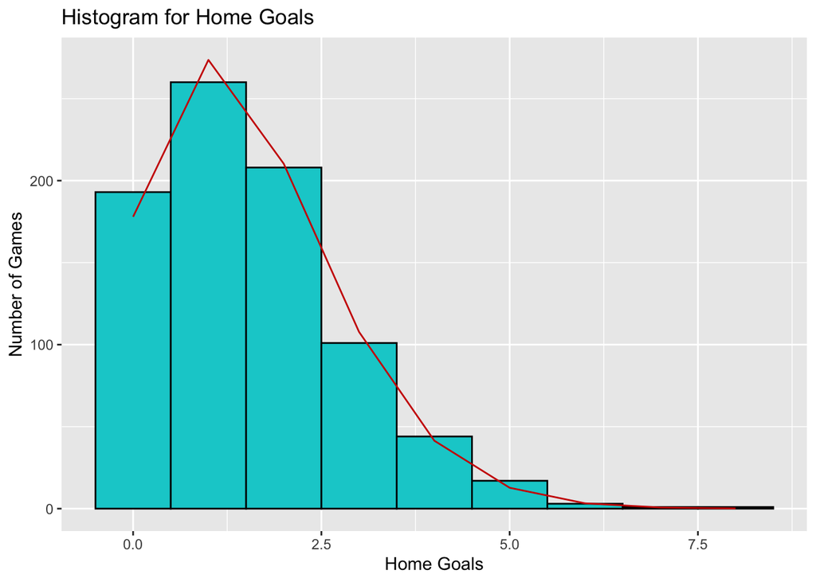

```r
qplot(dataset$FTHG, geom = "histogram", xlab = "Home Goals",
    ylab = "Number of Games", main = "Histogram for Home Goals",
    col = I("black"), fill = I("darkturquoise"), binwidth = 1) +
    geom_line(aes(xfit, exppois, col = I("red3")))
```

```r
xfit <- seq(min(dataset$FTAG), max(dataset$FTAG))
yfit <- dpois(xfit, lambda = mean(dataset$FTAG))
mean(dataset$FTAG)
```

```
## [1] 1.272947
```

The sample mean of Away Goals is 1.27 and it is used as Poisson distribuion mean. The expected number of games for each quantile in Poisson distribution is as follows. It can be seen in the following histogram.

```r
exppois <- as.numeric(length(dataset$FTAG)) * yfit
exppois
```

```
##  [1] 2.318444e+02 2.951256e+02 1.878396e+02 7.970326e+01 2.536451e+01
##  [6] 6.457533e+00 1.370016e+00 2.491368e-01 3.964224e-02 5.606941e-03
```

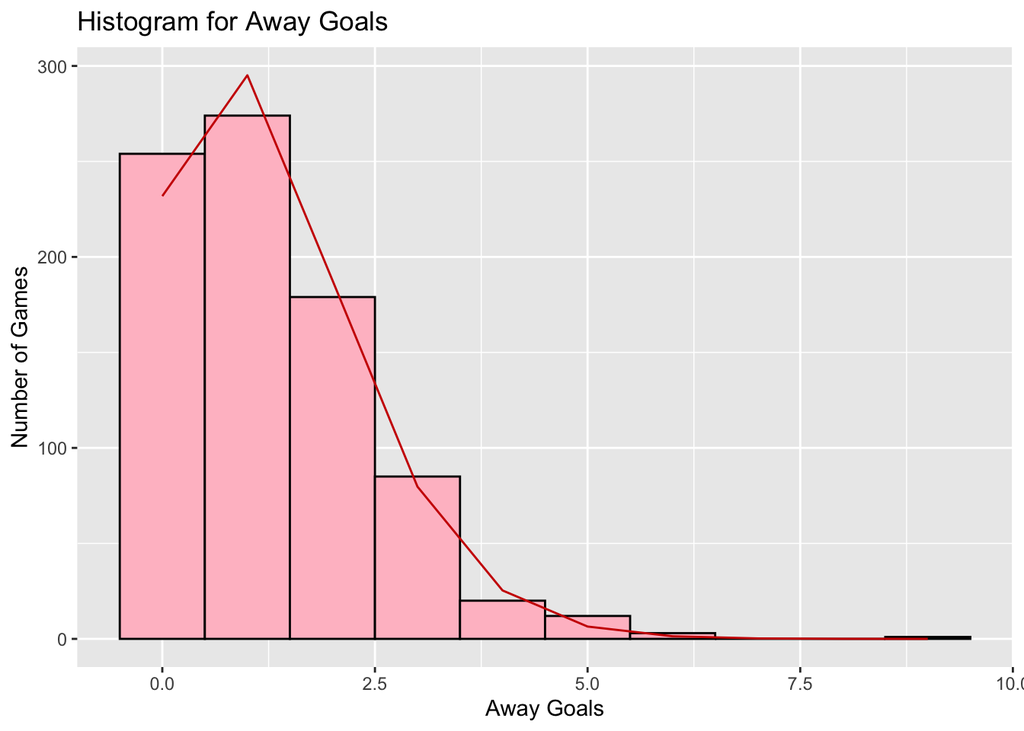

```r
qplot(dataset$FTAG, geom = "histogram", xlab = "Away Goals",
    ylab = "Number of Games", main = "Histogram for Away Goals",
    col = I("black"), fill = I("pink"), binwidth = 1) + geom_line(aes(xfit,
    exppois, col = I("red3")))
```

## Task 2

### Part 1

The probabilities of “home win”, “tie” and “away win” results for each bookmaker are calculated according to “P(x) = 1/odd”.

```r
# subset of odd values of four bookmakers and calculating
# probabilities
grep(c("B365H"), colnames(dataset))
```

```
## [1] 24
```

```r
grep(c("PSA"), colnames(dataset))
```

```
## [1] 35
```

```r
odds <- dataset[, 24:35]
probs <- 1/odds
colnames(probs) <- paste0(rep("prob", 12), colnames(probs))
dataset <- cbind(dataset, probs)
head(dataset[, 126:137])
```

```
##    probB365H probB365D probB365A   probBWH   probBWD   probBWA   probIWH
## 1: 0.6369427 0.2564103 0.1333333 0.6535948 0.2500000 0.1333333 0.6451613
## 2: 0.5263158 0.2777778 0.2222222 0.5263158 0.2941176 0.2272727 0.5263158
## 3: 0.4000000 0.2941176 0.3333333 0.4081633 0.3030303 0.3389831 0.4166667
## 4: 0.1538462 0.2500000 0.6211180 0.1600000 0.2564103 0.6369427 0.1612903
## 5: 0.2564103 0.2857143 0.4901961 0.2631579 0.2857143 0.5000000 0.2702703
## 6: 0.4219409 0.3125000 0.2941176 0.4255319 0.3225806 0.3030303 0.4545455
##      probIWD   probIWA   probPSH   probPSD   probPSA
## 1: 0.2631579 0.1428571 0.6329114 0.2544529 0.1333333
## 2: 0.2857143 0.2439024 0.5291005 0.2754821 0.2183406
## 3: 0.3030303 0.3389831 0.4000000 0.2890173 0.3333333
## 4: 0.2500000 0.6451613 0.1560062 0.2487562 0.6172840
## 5: 0.2985075 0.4878049 0.2610966 0.2801120 0.4807692
## 6: 0.3030303 0.2941176 0.4115226 0.3105590 0.3003003
```

### Part 2

The probabilities are calculated again with normalization formula.

```r
# normalization
attach(dataset)
dataset <- cbind(dataset, nprobB365H = probB365H * (1/(probB365H +
    probB365D + probB365A)), nprobB365D = probB365D * (1/(probB365H +
    probB365D + probB365A)), nprobB365A = probB365A * (1/(probB365H +
    probB365D + probB365A)))

dataset <- cbind(dataset, nprobBWH = probBWH * (1/(probBWH +
    probBWD + probBWA)), nprobBWD = probBWD * (1/(probBWH + probBWD +
    probBWA)), nprobBWA = probBWA * (1/(probBWH + probBWD + probBWA)))

dataset <- cbind(dataset, nprobIWH = probIWH * (1/(probIWH +
    probIWD + probIWA)), nprobIWD = probIWD * (1/(probIWH + probIWD +
    probIWA)), nprobIWA = probIWA * (1/(probIWH + probIWD + probIWA)))

dataset <- cbind(dataset, nprobPSH = probPSH * (1/(probPSH +
    probPSD + probPSA)), nprobPSD = probPSD * (1/(probPSH + probPSD +
    probPSA)), nprobPSA = probPSA * (1/(probPSH + probPSD + probPSA)))
head(dataset[, 138:149])
```

```
##    nprobB365H nprobB365D nprobB365A  nprobBWH  nprobBWD  nprobBWA  nprobIWH
## 1:  0.6203869  0.2497455  0.1298677 0.6303183 0.2410968 0.1285849 0.6137517
## 2:  0.5128205  0.2706553  0.2165242 0.5023506 0.2807253 0.2169241 0.4984370
## 3:  0.3893130  0.2862595  0.3244275 0.3886615 0.2885518 0.3227867 0.3935719
## 4:  0.1500991  0.2439110  0.6059900 0.1518959 0.2434229 0.6046812 0.1526718
## 5:  0.2483824  0.2767689  0.4748487 0.2508961 0.2724014 0.4767025 0.2557966
## 6:  0.4102255  0.3038232  0.2859513 0.4048279 0.3068856 0.2882865 0.4322034
##     nprobIWD  nprobIWA  nprobPSH  nprobPSD  nprobPSA
## 1: 0.2503461 0.1359022 0.6200772 0.2492931 0.1306296
## 2: 0.2705801 0.2309830 0.5172436 0.2693087 0.2134477
## 3: 0.2862341 0.3201941 0.3912552 0.2826988 0.3260460
## 4: 0.2366412 0.6106870 0.1526411 0.2433903 0.6039686
## 5: 0.2825217 0.4616817 0.2554817 0.2740882 0.4704302
## 6: 0.2881356 0.2796610 0.4025136 0.3037603 0.2937261
```

### Part 3

P(home win) - P(away win) values are calculated for each bookmaker and stored as new variables. Then these values discretized into bins.

```r
# creating P(home win) - P(away win) values for each
# bookmaker
dataset$home_awayB365 <- dataset$nprobB365H - dataset$nprobB365A
dataset$home_awayBW <- dataset$nprobBWH - dataset$nprobBWA
dataset$home_awayIW <- dataset$nprobIWH - dataset$nprobIWA
dataset$home_awayPS <- dataset$nprobPSH - dataset$nprobPSA

# creating bins for each bookmaker
values <- c(-1, -0.8, -0.6, -0.4, -0.2, 0, 0.2, 0.4, 0.6, 0.8,
    1)
bins <- c("bin1", "bin2", "bin3", "bin4", "bin5", "bin6", "bin7",
    "bin8", "bin9", "bin10")
dataset <- dataset %>% mutate(bin_B365 = cut(dataset$home_awayB365,
    breaks = values, labels = bins))
dataset <- dataset %>% mutate(bin_BW = cut(dataset$home_awayBW,
    breaks = values, labels = bins))
dataset <- dataset %>% mutate(bin_IW = cut(dataset$home_awayIW,
    breaks = values, labels = bins))
dataset <- dataset %>% mutate(bin_PS = cut(dataset$home_awayPS,
    breaks = values, labels = bins))
```

The ratio of the games ended as draw to the total number of games in each bin is calculated for each bookmaker. This gives the estimated probabilities of draw games.

```r
# actual results - B365
total_B365 <- as.numeric(table(dataset$bin_B365))
draw_B365 <- as.numeric(table(dataset$bin_B365[dataset$FTR ==
    "D"]))
prob_bins_B365 <- draw_B365/total_B365
prob_bins_B365[is.na(prob_bins_B365)] = 0
prob_bins_B365
```

```
##  [1] 0.00000000 0.07692308 0.14035088 0.20731707 0.20869565 0.31578947
##  [7] 0.26315789 0.21138211 0.09411765 0.04761905
```

```r
# actual results - BW
total_BW <- as.numeric(table(dataset$bin_BW))
draw_BW <- as.numeric(table(dataset$bin_BW[dataset$FTR == "D"]))
prob_bins_BW <- draw_BW/total_BW
prob_bins_BW[is.na(prob_bins_BW)] = 0
prob_bins_BW
```

```
##  [1] 0.00000000 0.07692308 0.14814815 0.18681319 0.20000000 0.32163743
##  [7] 0.27536232 0.18644068 0.10465116 0.06250000
```

```r
# actual results - IW
total_IW <- as.numeric(table(dataset$bin_IW))
draw_IW <- as.numeric(table(dataset$bin_IW[dataset$FTR == "D"]))
prob_bins_IW <- draw_IW/total_IW
prob_bins_IW[is.na(prob_bins_IW)] = 0
prob_bins_IW
```

```
##  [1] 0.00000000 0.09677419 0.14035088 0.16279070 0.22131148 0.30386740
##  [7] 0.26351351 0.18750000 0.09876543 0.10000000
```

```r
# actual results - PS
total_PS <- as.numeric(table(dataset$bin_PS))
draw_PS <- as.numeric(table(dataset$bin_PS[dataset$FTR == "D"]))
prob_bins_PS <- draw_PS/total_PS
prob_bins_PS[is.na(prob_bins_PS)] = 0
prob_bins_PS
```

```
##  [1] 0.00000000 0.07500000 0.14814815 0.19540230 0.19819820 0.32571429
##  [7] 0.24812030 0.21848739 0.10465116 0.04545455
```

Plots of P(home win) - P(away win) and P(tie) are as follows. Circles represents the normalized probabilites. Squares represent the estimated probabilites of draw games.

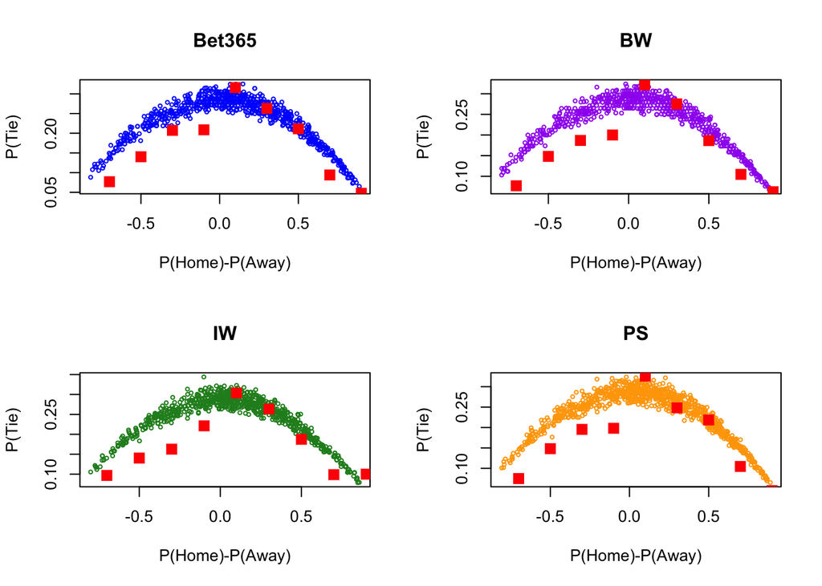

```r
# plots of P(home win) - P(away win) and P (tie)
mean_values <- c(-0.9, -0.7, -0.5, -0.3, -0.1, 0.1, 0.3, 0.5,
    0.7, 0.9)
par(mfrow = c(2, 2))
plot(dataset$home_awayB365, dataset$nprobB365D, cex = 0.5, col = "blue",
    xlab = "P(Home)-P(Away)", ylab = "P(Tie)", main = "Bet365")
points(mean_values, prob_bins_B365, cex = 1.5, col = "red", pch = 15)

plot(dataset$home_awayBW, dataset$nprobBWD, cex = 0.5, col = "purple",
    xlab = "P(Home)-P(Away)", ylab = "P(Tie)", main = "BW")
points(mean_values, prob_bins_BW, cex = 1.5, col = "red", pch = 15)

plot(dataset$home_awayIW, dataset$nprobIWD, cex = 0.5, col = "forestgreen",
    xlab = "P(Home)-P(Away)", ylab = "P(Tie)", main = "IW")
points(mean_values, prob_bins_IW, cex = 1.5, col = "red", pch = 15)

plot(dataset$home_awayPS, dataset$nprobPSD, cex = 0.5, col = "orange",
    xlab = "P(Home)-P(Away)", ylab = "P(Tie)", main = "PS")
points(mean_values, prob_bins_PS, cex = 1.5, col = "red", pch = 15)
```

## Task 3

A subset of games without a red card is created.

```r
without_redcard <- subset(dataset, (dataset$HR == 0 & dataset$AR ==
    0))
```

The estimated probabilities of draw games in each bin calculated again with new dataset.

```r
# actual results - B365
total_B365_red <- as.numeric(table(without_redcard$bin_B365))
draw_B365_red <- as.numeric(table(without_redcard$bin_B365[without_redcard$FTR ==
    "D"]))
prob_bins_B365_red <- draw_B365_red/total_B365_red
prob_bins_B365_red[is.na(prob_bins_B365)] = 0
prob_bins_B365_red
```

```
##  [1] 0.00000000 0.08108108 0.15384615 0.19178082 0.19780220 0.33093525
##  [7] 0.26446281 0.22222222 0.10126582 0.05000000
```

```r
# actual results - BW
total_BW_red <- as.numeric(table(without_redcard$bin_BW))
draw_BW_red <- as.numeric(table(without_redcard$bin_BW[without_redcard$FTR ==
    "D"]))
prob_bins_BW_red <- draw_BW_red/total_BW_red
prob_bins_BW_red[is.na(prob_bins_BW)] = 0
prob_bins_BW_red
```

```
##  [1]        NaN 0.07894737 0.16666667 0.17073171 0.20000000 0.32608696
##  [7] 0.28346457 0.19469027 0.11250000 0.06666667
```

```r
# actual results - IW
total_IW_red <- as.numeric(table(without_redcard$bin_IW))
draw_IW_red <- as.numeric(table(without_redcard$bin_IW[without_redcard$FTR ==
    "D"]))
prob_bins_IW_red <- draw_IW_red/total_IW_red
prob_bins_IW_red[is.na(prob_bins_IW)] = 0
prob_bins_IW_red
```

```
##  [1]        NaN 0.09677419 0.15686275 0.15584416 0.20833333 0.31543624
##  [7] 0.26470588 0.19626168 0.10666667 0.11111111
```

```r
# actual results - PS
total_PS_red <- as.numeric(table(without_redcard$bin_PS))
draw_PS_red <- as.numeric(table(without_redcard$bin_PS[without_redcard$FTR ==
    "D"]))
prob_bins_PS_red <- draw_PS_red/total_PS_red
prob_bins_PS_red[is.na(prob_bins_PS)] = 0
prob_bins_PS_red
```

```
##  [1] 0.00000000 0.07894737 0.16326531 0.17948718 0.19318182 0.33333333
##  [7] 0.25619835 0.22807018 0.11250000 0.04761905
```

Plots of P(home win) - P(away win) and P(tie) are as follows. Circles represents the normalized probabilites. Squares represent the estimated probabilites of draw games in all games. Triangulars are represent the estimated probabilities of draw games in only the games without red cards.

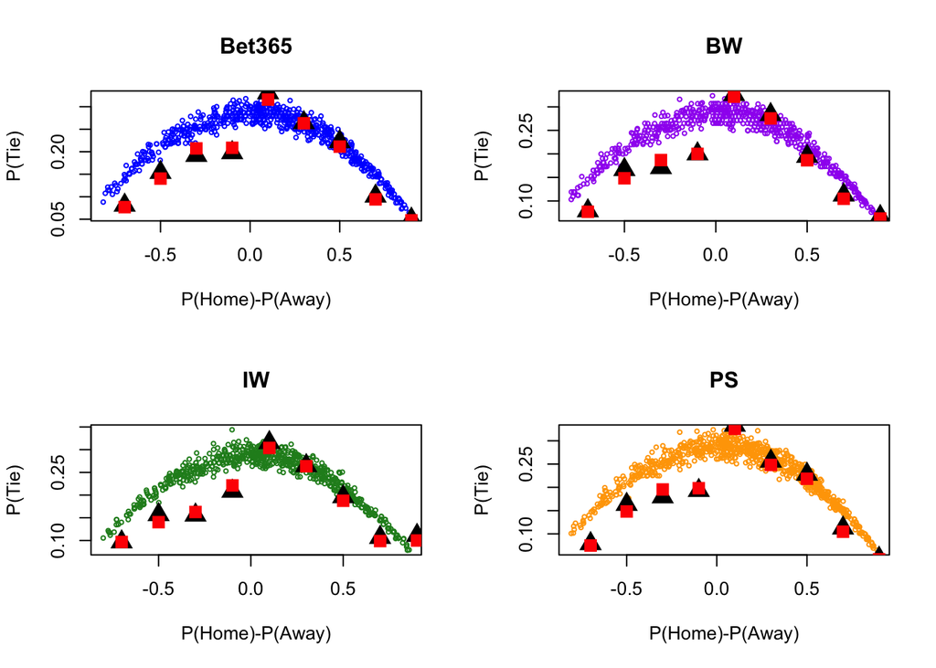

```r
# plots of P(home win) ??? P(away win) and P (tie)
par(mfrow = c(2, 2))
plot(without_redcard$home_awayB365, without_redcard$nprobB365D,
    cex = 0.5, col = "blue", xlab = "P(Home)-P(Away)", ylab = "P(Tie)",
    main = "Bet365")
points(mean_values, prob_bins_B365_red, cex = 2, col = "black",
    pch = 17)
points(mean_values, prob_bins_B365, cex = 1.5, col = "red", pch = 15)

plot(without_redcard$home_awayBW, without_redcard$nprobBWD, cex = 0.5,
    col = "purple", xlab = "P(Home)-P(Away)", ylab = "P(Tie)",
    main = "BW")
points(mean_values, prob_bins_BW_red, cex = 2, col = "black",
    pch = 17)
points(mean_values, prob_bins_BW, cex = 1.5, col = "red", pch = 15)

plot(without_redcard$home_awayIW, without_redcard$nprobIWD, cex = 0.5,
    col = "forestgreen", xlab = "P(Home)-P(Away)", ylab = "P(Tie)",
    main = "IW")
points(mean_values, prob_bins_IW_red, cex = 2, col = "black",
    pch = 17)
points(mean_values, prob_bins_IW, cex = 1.5, col = "red", pch = 15)

plot(without_redcard$home_awayPS, without_redcard$nprobPSD, cex = 0.5,
    col = "orange", xlab = "P(Home)-P(Away)", ylab = "P(Tie)",
    main = "PS")
points(mean_values, prob_bins_PS_red, cex = 2, col = "black",
    pch = 17)
points(mean_values, prob_bins_PS, cex = 1.5, col = "red", pch = 15)
```

There are no significant change in the observations compared to Task 2.